# C1 Data Challenge

### Data Science Challenge: Card Transactions

#### This Notebook aims to analyze the credit card fraud based on the card transactions data. It consists of five parts:

(1) Data loading and a brief summary of the data strucutre

(2) Visualization of the features in the data (transactionAmount, etc.)

(3) Analyze two types of the duplicate transactions: reversal & multi-swipe

(4) An Xgboost model is built to predict the fraud and the important indicators of the fraud

(5) Caveats and Future steps

#### Part 1: Data Load

The transaction data consists of 786,363 transactions and 29 variables. The transactions is from 5,000 unique accounts and customers.

For each record, the variables include card information (CVV, credit limit, balance, etc.), transaction information (transaction time, amount, etc.), mechant information (merchant name, category, etc.).

The flag 'isFraud' indicate if the transaction is Fraud, and there is 1.58% fraud in the given data.

For categorical and boolean variables, the bar plot is used to visualize the unique value and distribution. For numerical variables, the descriptive analysis is conducted, as well as historgam and boxplot are used to check the distribution (Plots in Part 2).

```python
import os
import pandas as pd
import numpy as np
import json
import warnings
import seaborn as sns
import matplotlib.pyplot as plt
%matplotlib inline
from sklearn.impute import SimpleImputer
from sklearn.model_selection import train_test_split
from sklearn.model_selection import cross_val_score
from sklearn.metrics import plot_confusion_matrix
import xgboost as xgb
from sklearn.model_selection import GridSearchCV
from sklearn.model_selection import ParameterGrid
from sklearn import metrics
from sklearn.metrics import confusion_matrix
import shap
```

```python
os.chdir('~/Desktop')
```

```python
pd.set_option('display.max_columns', None)
warnings.filterwarnings('ignore')
```

```python
lst = []
for line in open('transactions.txt', 'r'):
    lst.append(json.loads(line))
df = pd.DataFrame(lst)
df.replace('', np.nan, inplace=True)
```

```python
df.head()
```

|  | accountNumber | customerId | creditLimit | availableMoney | transactionDateTime | transactionAmount | merchantName | acqCountry | merchantCountryCode | posEntryMode | posConditionCode | merchantCategoryCode | currentExpDate | accountOpenDate | dateOfLastAddressChange | cardCVV | enteredCVV | cardLast4Digits | transactionType | echoBuffer | currentBalance | merchantCity | merchantState | merchantZip | cardPresent | posOnPremises | recurringAuthInd | expirationDateKeyInMatch | isFraud |
| --- | --- | --- | --- | --- | --- | --- | --- | --- | --- | --- | --- | --- | --- | --- | --- | --- | --- | --- | --- | --- | --- | --- | --- | --- | --- | --- | --- | --- | --- |
| 0 | 737265056 | 737265056 | 5000.0 | 5000.0 | 2016-08-13T14:27:32 | 98.55 | Uber | US | US | 02 | 01 | rideshare | 06/2023 | 2015-03-14 | 2015-03-14 | 414 | 414 | 1803 | PURCHASE | NaN | 0.0 | NaN | NaN | NaN | False | NaN | NaN | False | False |
| 1 | 737265056 | 737265056 | 5000.0 | 5000.0 | 2016-10-11T05:05:54 | 74.51 | AMC #191138 | US | US | 09 | 01 | entertainment | 02/2024 | 2015-03-14 | 2015-03-14 | 486 | 486 | 767 | PURCHASE | NaN | 0.0 | NaN | NaN | NaN | True | NaN | NaN | False | False |
| 2 | 737265056 | 737265056 | 5000.0 | 5000.0 | 2016-11-08T09:18:39 | 7.47 | Play Store | US | US | 09 | 01 | mobileapps | 08/2025 | 2015-03-14 | 2015-03-14 | 486 | 486 | 767 | PURCHASE | NaN | 0.0 | NaN | NaN | NaN | False | NaN | NaN | False | False |
| 3 | 737265056 | 737265056 | 5000.0 | 5000.0 | 2016-12-10T02:14:50 | 7.47 | Play Store | US | US | 09 | 01 | mobileapps | 08/2025 | 2015-03-14 | 2015-03-14 | 486 | 486 | 767 | PURCHASE | NaN | 0.0 | NaN | NaN | NaN | False | NaN | NaN | False | False |
| 4 | 830329091 | 830329091 | 5000.0 | 5000.0 | 2016-03-24T21:04:46 | 71.18 | Tim Hortons #947751 | US | US | 02 | 01 | fastfood | 10/2029 | 2015-08-06 | 2015-08-06 | 885 | 885 | 3143 | PURCHASE | NaN | 0.0 | NaN | NaN | NaN | True | NaN | NaN | False | False |

```python
"Transaction data has {} observations and {} variables".format(df.shape[0], df.shape[1])
```

```
'Transaction data has 786363 observations and 29 variables'
```

##### Check Missingness

```python
#df.info()
```

```python
# check missing values of the data
df.isnull().sum()
```

```
accountNumber                    0
customerId                       0
creditLimit                      0
availableMoney                   0
transactionDateTime              0
transactionAmount                0
merchantName                     0
acqCountry                    4562
merchantCountryCode            724
posEntryMode                  4054
posConditionCode               409
merchantCategoryCode             0
currentExpDate                   0
accountOpenDate                  0
dateOfLastAddressChange          0
cardCVV                          0
enteredCVV                       0
cardLast4Digits                  0
transactionType                698
echoBuffer                  786363
currentBalance                   0
merchantCity                786363
merchantState               786363
merchantZip                 786363
cardPresent                      0
posOnPremises               786363
recurringAuthInd            786363
expirationDateKeyInMatch         0
isFraud                          0
dtype: int64
```

```python
# remove variable with 100% missing value
df.drop(['echoBuffer','merchantCity', 'merchantState', 'merchantZip', 'posOnPremises', 'recurringAuthInd'], axis=1, inplace=True)
```

##### check unique values for categorical variable

```python
obj_list = df.select_dtypes(include=['object']).columns
```

```python
"The {} transactions are from {} unique accounts, {} unique customers".format(df.shape[0], df.accountNumber.nunique(),df.customerId.nunique())
```

```
'The 786363 transactions are from 5000 unique accounts, 5000 unique customers'
```

```python
# check acctNumber and customerId are one-on-one match
len(set(zip(df['accountNumber'],df['customerId'])))
```

```
5000
```

```python
'The accounts with {} unique open date range from {} to {}'.format(df.accountOpenDate.nunique(),min(df.accountOpenDate), max(df.accountOpenDate))
```

```
'The accounts with 1820 unique open date range from 1989-08-22 to 2015-12-31'
```

```python
'The data has {} unique card CVV and {} unique entered card CVV. The account has {} unique last 4 digit and {} unique expiration date'.format(df.cardCVV.nunique(), df.enteredCVV.nunique(),df.cardLast4Digits.nunique(), df.currentExpDate.nunique())
```

```
'The data has 899 unique card CVV and 976 unique entered card CVV. The account has 5246 unique last 4 digit and 165 unique expiration date'
```

```python
'The data involves transactions with {} unique merchant'.format(df.merchantName.nunique())
```

```
'The data involves transactions with 2490 unique merchant'
```

```python
'The data has {} unique date of last address change'.format(df.dateOfLastAddressChange.nunique())
```

```
'The data has 2184 unique date of last address change'
```

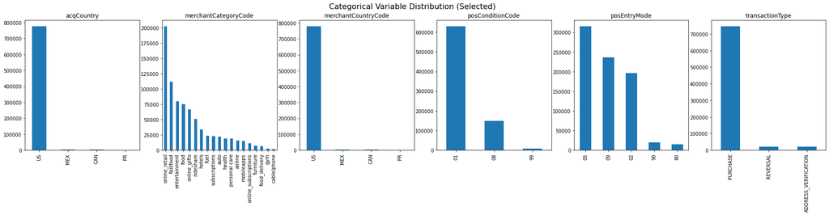

```python
cat_vars = ['acqCountry','merchantCategoryCode','merchantCountryCode','posConditionCode','posEntryMode','transactionType']

fig1, ax1 = plt.subplots(1,len(cat_vars), figsize=(30,5))
for i, cat_var in enumerate(df[cat_vars]):
    df[cat_var].value_counts().plot(kind="bar", ax=ax1[i]).set_title(cat_var)
fig1.suptitle('Categorical Variable Distribution (Selected)', fontsize=16)
```

##### Check Boolean

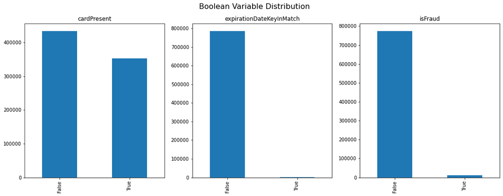

```python
bool_list = df.select_dtypes(include=['bool']).columns
fig2, ax2 = plt.subplots(1, len(bool_list), figsize=(18,6))
for i, bool_var in enumerate(df[bool_list]):
    df[bool_var].value_counts().plot(kind="bar", ax=ax2[i]).set_title(bool_var)
fig2.suptitle('Boolean Variable Distribution', fontsize=16)
```

##### Check summary descriptives of numeric variable

```python
float_list = df.select_dtypes(include=['float64']).columns
df[float_list].describe()
```

|  | creditLimit | availableMoney | transactionAmount | currentBalance |
| --- | --- | --- | --- | --- |
| count | 786363.000000 | 786363.000000 | 786363.000000 | 786363.000000 |
| mean | 10759.464459 | 6250.725369 | 136.985791 | 4508.739089 |
| std | 11636.174890 | 8880.783989 | 147.725569 | 6457.442068 |
| min | 250.000000 | -1005.630000 | 0.000000 | 0.000000 |
| 25% | 5000.000000 | 1077.420000 | 33.650000 | 689.910000 |
| 50% | 7500.000000 | 3184.860000 | 87.900000 | 2451.760000 |
| 75% | 15000.000000 | 7500.000000 | 191.480000 | 5291.095000 |
| max | 50000.000000 | 50000.000000 | 2011.540000 | 47498.810000 |

#### Part 2: Visualization of Numeric Variables

This part plots the boxplot and histrogram of four numeric variables in the data.

In overall, the variables are right skewed distributed, and some outliers are detected from the boxplot

##### Summary of numerical variable distribution

- Credit Limit:

  Based on the histogram, the variable is more like a discrete variable, and the distribution shows multi-peaks (5,000, 15,000, 50,000). But most of the values are between 0 ~ 25,000.
- Available money

  The histogram is right skewed. Most of the available amount is in 0 - 10,000. Also there is negative available money detected.
- Transaction amount

  As previous two variables, the distribution is also right skewed. Most of the transactions are between 0- 500. But some large amount transaction as high as $2,000 is observed
- Current balance

  Also right skewed distribution. In overall the value is between 0 - 10,000. There are some extreme large balance close to the highest credit limit (~50,000)

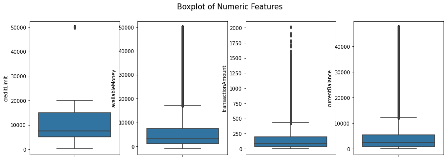

```python
fig3, ax3 = plt.subplots(1, len(float_list), figsize=(15,5))
for i in range(len(float_list)):
    sns.boxplot(y = df[float_list[i]], ax = ax3[i], orient='v')
plt.suptitle('Boxplot of Numeric Features', fontsize=15)
```

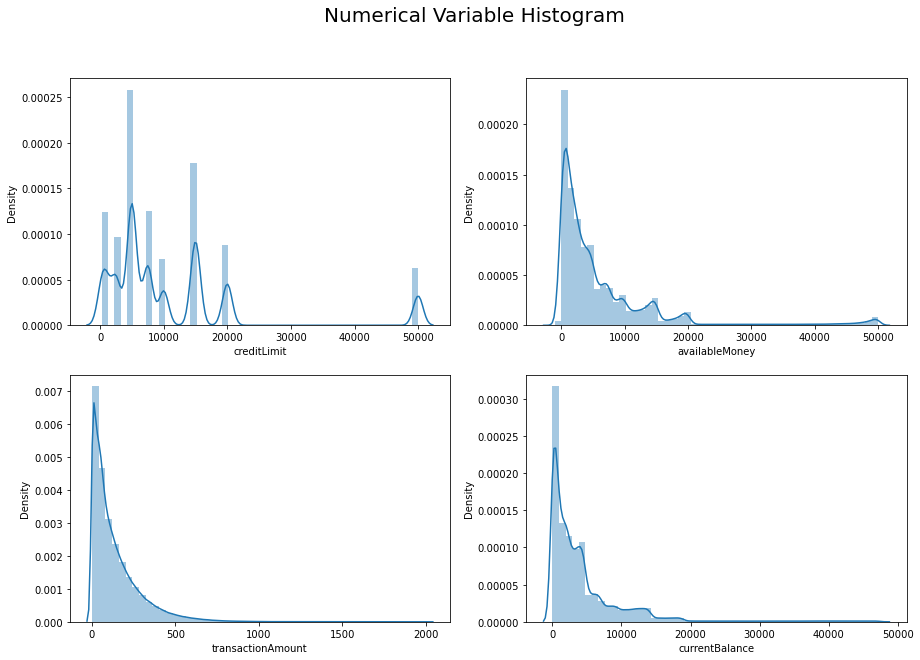

```python
fig4, ax4 = plt.subplots(nrows=2, ncols=2, figsize=(15,10))
float_vars = ['creditLimit', 'availableMoney', 'transactionAmount', 'currentBalance']
pos = 0

for i in range(2):
    for j in range(2):
        sns.distplot(df[float_vars[pos]], ax=ax4[i][j])
        pos+=1

fig4.suptitle('Numerical Variable Histogram', fontsize=20)
```

#### Part 3. Duplicate Transactions

In this section, the logic of reversal and multi-swipe transactions are programmed.

The reversal transactions are located based on the 'transactionType' equals 'REVERSAL'; the multi-swipe transactions are defined based on duplication in multiple keys (all keys exclude available money, current balance, and transaction time but keep the transaction date the same day), only the first payment is considered normal transaction, the rest of them are consider as duplicates.

- There are 20,303 reveral transactions with total amount of $2,821,792
- There are 7,628 multi-swipe transactions with total amount of $1,097,270.99

Both of the duplicate categories have Fraud rate of 1.7%, slightly higher than the rate in total transaction.

The distribution of categorical and numeric variables are checked and they are similar with the transaction data. So it could be a random scenario based on the given data.

##### reversal transaction

```python
reversal = df[df.transactionType =='REVERSAL']
```

```python
'There are {} reveral transaction with {} total dollar amount'.format(reversal.shape[0], round(sum(reversal['transactionAmount']),2))
```

```
'There are 20303 reveral transaction with 2821792.5 total dollar amount'
```

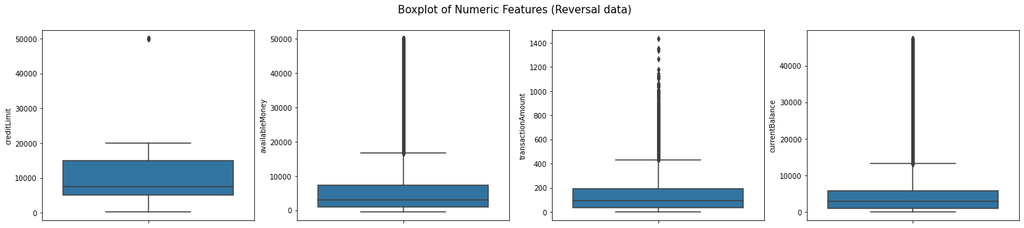

```python
fig5, ax5 = plt.subplots(1, len(float_list), figsize=(25,5))
for i in range(len(float_list)):
    sns.boxplot(y = reversal[float_list[i]], ax = ax5[i], orient='v')
plt.suptitle('Boxplot of Numeric Features (Reversal data)', fontsize=15)
```

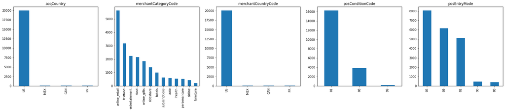

```python
cat_vars = ['acqCountry','merchantCategoryCode','merchantCountryCode','posConditionCode','posEntryMode']

fig6, ax6 = plt.subplots(1,len(cat_vars), figsize=(30,5))
for i, cat_var in enumerate(reversal[cat_vars]):
    reversal[cat_var].value_counts().plot(kind="bar", ax=ax6[i]).set_title(cat_var)
fig1.suptitle('Categorical Variable Distribution (Reversal)', fontsize=16)
```

##### multi-swipe

```python
# split transaction datetime to date and time
df['transactionDate'] = pd.to_datetime(df['transactionDateTime']).dt.date
df['transactionTime'] = pd.to_datetime(df['transactionDateTime']).dt.timetz
```

```python
# obtain multi-swipe subset
cols = ['accountNumber','customerId','creditLimit',
        'transactionAmount','merchantName','acqCountry',
        'merchantCountryCode','posEntryMode','posConditionCode','merchantCategoryCode',
        'currentExpDate','accountOpenDate','dateOfLastAddressChange','cardCVV','enteredCVV',
        'cardLast4Digits','transactionType','cardPresent','expirationDateKeyInMatch',
        'transactionDate']
multiswipe = df[df.duplicated(subset = cols, keep = 'first')]
```

```python
'There are {} multi-swipe transaction with {} total dollar amount'.format(multiswipe.shape[0], round(sum(multiswipe['transactionAmount']),2))
```

```
'There are 7628 multi-swipe transaction with 1097270.99 total dollar amount'
```

```python
multiswipe.head()
```

|  | accountNumber | customerId | creditLimit | availableMoney | transactionDateTime | transactionAmount | merchantName | acqCountry | merchantCountryCode | posEntryMode | posConditionCode | merchantCategoryCode | currentExpDate | accountOpenDate | dateOfLastAddressChange | cardCVV | enteredCVV | cardLast4Digits | transactionType | currentBalance | cardPresent | expirationDateKeyInMatch | isFraud | transactionDate | transactionTime |
| --- | --- | --- | --- | --- | --- | --- | --- | --- | --- | --- | --- | --- | --- | --- | --- | --- | --- | --- | --- | --- | --- | --- | --- | --- | --- |
| 263 | 984504651 | 984504651 | 50000.0 | 26680.99 | 2016-03-12T06:34:29 | 118.52 | AMC #706324 | US | US | 02 | 01 | entertainment | 10/2024 | 2015-07-27 | 2015-07-27 | 640 | 640 | 8332 | PURCHASE | 23319.01 | True | False | False | 2016-03-12 | 06:34:29 |
| 264 | 984504651 | 984504651 | 50000.0 | 26562.47 | 2016-03-12T06:36:41 | 118.52 | AMC #706324 | US | US | 02 | 01 | entertainment | 10/2024 | 2015-07-27 | 2015-07-27 | 640 | 640 | 8332 | PURCHASE | 23437.53 | True | False | False | 2016-03-12 | 06:36:41 |
| 281 | 984504651 | 984504651 | 50000.0 | 24316.12 | 2016-03-18T13:57:04 | 26.71 | Planet Fitness #692929 | US | US | 02 | 01 | health | 10/2024 | 2015-07-27 | 2015-07-27 | 640 | 640 | 8332 | PURCHASE | 25683.88 | True | False | False | 2016-03-18 | 13:57:04 |
| 339 | 984504651 | 984504651 | 50000.0 | 16503.49 | 2016-04-08T22:21:11 | 43.21 | WSC #994275 | US | US | 02 | 08 | health | 02/2030 | 2015-07-27 | 2016-03-26 | 640 | 640 | 8332 | PURCHASE | 33496.51 | False | False | False | 2016-04-08 | 22:21:11 |
| 413 | 984504651 | 984504651 | 50000.0 | 7302.32 | 2016-05-07T07:32:54 | 23.82 | Golds Gym #846582 | US | US | 09 | 01 | health | 12/2030 | 2015-07-27 | 2016-05-05 | 640 | 640 | 8332 | PURCHASE | 42697.68 | True | False | False | 2016-05-07 | 07:32:54 |

```python
multiswipe.isFraud.mean()
```

```
0.016649187205034086
```

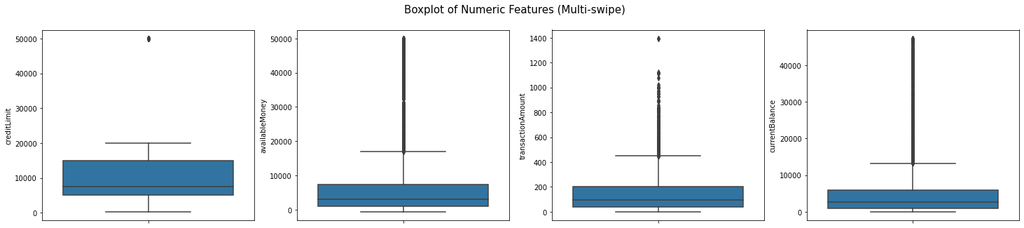

```python
fig7, ax7 = plt.subplots(1, len(float_list), figsize=(25,5))
for i in range(len(float_list)):
    sns.boxplot(y = multiswipe[float_list[i]], ax = ax7[i], orient='v')
plt.suptitle('Boxplot of Numeric Features (Multi-swipe)', fontsize=15)
```

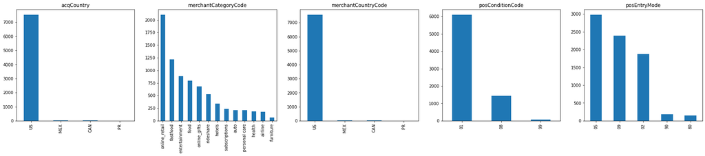

```python
cat_vars = ['acqCountry','merchantCategoryCode','merchantCountryCode','posConditionCode','posEntryMode']

fig8, ax8 = plt.subplots(1,len(cat_vars), figsize=(30,5))
for i, cat_var in enumerate(multiswipe[cat_vars]):
    multiswipe[cat_var].value_counts().plot(kind="bar", ax=ax8[i]).set_title(cat_var)
fig1.suptitle('Categorical Variable Distribution (Multi-swipe)', fontsize=16)
```

#### Part 4 Modeling

This part consists of two steps:

- Data Preprocess
  - Missing data in the categorical variables are replaced with the most frequent value
  - Dummy coded the categorical variables
  - Self-defined variable (CVV match or not)
  - Randomly split the data to train & test portions (70%:30%)
- Modeling
  - XGBoost models is utlized, and best model obtained based on the Grid Search and F1 score is used as a criteria since it's imbalanced data
  - The performance is evaluated based on F1 score (0.097), and confusion matrix is visualized
  - Variable importance visualized based on Shap value
    - The higher the transaction amount, the higher possibility it might be fraud
    - PosEntry Mode 09 has higher chance of fraudulent transaction and PosEntry Mode 05 seems more reliable.
    - When Card not present at purchase, it is more chance to be a fraud
    - The fuel, mobile apps, health, online subscription mechant purchase has less likely to be fraud, while online purchase and airlines have higher chance of fraud

#### Data Preprocess

```python
# recode boolean
for col in ['cardPresent', 'expirationDateKeyInMatch', 'isFraud']:
    df[col] = df[col].replace({False: 0, True: 1})
```

```python
# replace missing values
var_w_miss = ['acqCountry','merchantCountryCode','posConditionCode','posEntryMode','transactionType']
imp = SimpleImputer(missing_values=np.nan, strategy='most_frequent')
for var in var_w_miss:
    df[var] = imp.fit_transform(df[var].values.reshape(-1,1))[:,0]
```

```python
# dummy code categorical variables
cat_vars = ['acqCountry',
      'merchantCountryCode',
      'posConditionCode',
      'posEntryMode',
      'merchantCategoryCode',
      'transactionType']
for var in cat_vars:
    df = pd.get_dummies(df,columns = [var])
```

```python
# self-defined variable
df['CVVmatch'] = np.where(df['cardCVV']==df['enteredCVV'],1,0)
```

```python
select_cols = [
#'accountNumber',
#'customerId',
'creditLimit',
'availableMoney',
#'transactionDateTime',
'transactionAmount',
#'merchantName',
#'currentExpDate',
#'accountOpenDate',
#'dateOfLastAddressChange',
#'cardCVV',
#'enteredCVV',
#'cardLast4Digits',
'currentBalance',
'cardPresent',
'expirationDateKeyInMatch',
#'acqCountry_CAN', # as default group
'acqCountry_MEX',
'acqCountry_PR',
'acqCountry_US',
#'merchantCountryCode_CAN', #as default group
'merchantCountryCode_MEX',
'merchantCountryCode_PR',
'merchantCountryCode_US',
#'posConditionCode_01', #as default group
'posConditionCode_08',
'posConditionCode_99',
#'posEntryMode_02', #as default group
'posEntryMode_05',
'posEntryMode_09',
'posEntryMode_80',
'posEntryMode_90',
'merchantCategoryCode_airline',
'merchantCategoryCode_auto',
'merchantCategoryCode_cable/phone',
'merchantCategoryCode_entertainment',
'merchantCategoryCode_fastfood',
'merchantCategoryCode_food',
'merchantCategoryCode_food_delivery',
'merchantCategoryCode_fuel',
'merchantCategoryCode_furniture',
'merchantCategoryCode_gym',
'merchantCategoryCode_health',
'merchantCategoryCode_hotels',
'merchantCategoryCode_mobileapps',
'merchantCategoryCode_online_gifts',
'merchantCategoryCode_online_retail',
'merchantCategoryCode_online_subscriptions',
'merchantCategoryCode_personal care',
'merchantCategoryCode_rideshare',
#'merchantCategoryCode_subscriptions', #as default group
#'transactionType_ADDRESS_VERIFICATION', #as default group
'transactionType_PURCHASE',
'transactionType_REVERSAL',
'isFraud']
```

```python
# prepare train-test datasets
df = df[select_cols]
X = df[select_cols[0:len(select_cols)-1]]
y = df['isFraud']
X_train, X_test, y_train, y_test = train_test_split(X, y, test_size = 0.3, random_state = 42)
```

##### Modeling - XGBoost

```python
# grid search
parameters =  {'objective':['reg:logistic'],
            'max_depth': [3,4,5,6],
            'learning_rate': [0.01, 0.05, 0.1],
            'n_estimators': [200, 250, 300, 350],
            'alpha':[0.01, 0.1, 0.5],
            'colsample_bytree': [0.3, 0.4, 0.6, 0.8],
            'scale_pos_weight':[30, 50, 70],
            }

xgb_model = xgb.XGBClassifier(random_state = 42)

grid = GridSearchCV(estimator = xgb_model, param_grid = parameters, scoring = 'f1', n_jobs = -1, cv = 3)

grid_result = grid.fit(X_train, y_train)
print("Best: %f using %s" % (grid_result.best_score_, grid_result.best_params_))
```

```
Best: 0.097453 using {'alpha': 0.5, 'colsample_bytree': 0.8, 'learning_rate': 0.1, 'max_depth': 5, 'n_estimators': 250, 'objective': 'reg:logistic', 'scale_pos_weight': 30}
```

```python
best_random =  grid_result.best_estimator_
```

```python
best_random.fit(X_train, y_train)
preds = best_random.predict(X_test)
```

```python
# extract key metrics
fpr, tpr, thresholds = metrics.roc_curve(y_test, preds, pos_label=1)
auc = metrics.auc(fpr, tpr).round(4)
print('AUC:', auc)
print('Precision: %.3f' % metrics.precision_score(y_test, preds))
print('Recall: %.3f' % metrics.recall_score(y_test, preds))
print('F-measure: %.3f' % metrics.f1_score(y_test, preds))
```

```
AUC: 0.6486
Precision: 0.055
Recall: 0.408
F-measure: 0.097
```

```
<sklearn.metrics._plot.confusion_matrix.ConfusionMatrixDisplay at 0x7fe7e6499280>
```

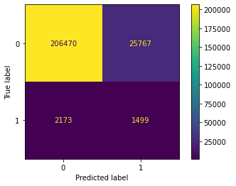

```python
plot_confusion_matrix(best_random, X_test, y_test)
```

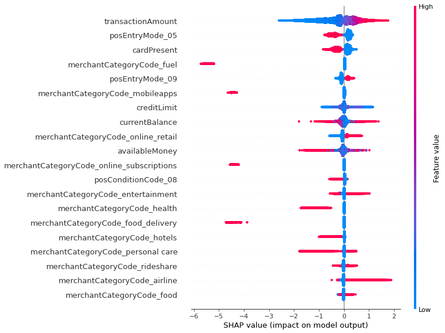

```python
explainer = shap.TreeExplainer(best_random)
shap_values = explainer.shap_values(X_test)
shap.summary_plot(shap_values, features=X_test, feature_names=X_test.columns) #summary plot
```

#### Part 5 Caveats and Next Steps

There are some efforts can be made in order to improve the model performance

- Missing data
  - Mechant geo info are all missing in current data, see if it can be obtained through other sources
  - Other missing variables is replaced by most frequent value, further missing data analysis can be conducted to figure out better ways to fill in the missingness
- Preprocess data
  - Binning the numeric variables to see if the performance improved
  - The current version use class weight in the Xbgoost package to handle imbalanced data, other approaches such as downsampling or SMOT to upsampling can be tried to see if there is improvement
- More feature engineering
  - Current data: consecutive purchases, account age, transaction number and time since address change date, etc.
  - Other potential data: payment history data, geographic information, etc.
- Try other algorithms
  - Try techniques like PCA for variable reduction, K-means, SVM, or stacking different models
  - Customize the loss function in grid search to make the model more suitable for imbalanced fraud detection data